# Starbucks Capstone Challenge

## Project Overview

In this project, I will try to find how Starbucks customers use the app, and how well is the current offers system. I will also see who should the app target in promotions. The data sets used in this project contains simulated data that mimics customer behavior on the Starbucks rewards mobile app. From it, we can understand the costumers' behavior and it might help us make better decisions.

## The Problem

The problem we have here is that we don't want to give any customer our offers. We want to give only those who we think will be able to complete the offer. Giving an offer to someone we know he/she probably will not be able to complete it is a waste of time and resources that can be given to someone who we know will complete it. I will approach this problem by first cleaning up the data, then doing some exploratory analysis and see who are my most valuable customers after that I will create a model to help us predicting feature customers and which type of offer should we give them.

# Analysis

### Part I: Business understanding

My objective here is to find patterns and show when and where to give specific offer to a specific customer. Main users of this kind of applications are Starbucks employees and analysts. The plan in this project to have questions and answer them with data visualization. Tha data is provided by Starbucks contains simulated data that mimics customer behavior.

### Part II: Data Exploration

In this project we were given 3 files. Before I start analyzing we have to explore and see what is the data we have. We need to check if it is clean or not, if each column have the right type that the data tell, for example if the data in column called price is saved as string, we need to convert it to number to help us in the analysis if we want to find the sum for example, having it as string will not return the total of that column. Similar thing goes to dates saved as strings.

```python
# import libraries
import pandas as pd
import numpy as np
import math
import json
import plotly
import plotly.graph_objs as go
import matplotlib.pyplot as plt
import seaborn as sns
plotly.offline.init_notebook_mode()
% matplotlib inline
from sklearn.preprocessing import MultiLabelBinarizer
```

```python
# read in the json files
portfolio = pd.read_json('data/portfolio.json', orient='records', lines=True)
profile = pd.read_json('data/profile.json', orient='records', lines=True)
transcript = pd.read_json('data/transcript.json', orient='records', lines=True)
```

### Part III: Data understanding

The data we have is provided by Starbucks. Here is a quick breakthrough of how the data looks like:

- 3 .json files.
  - portfolio.json - containing offer ids and meta data about each offer (duration, type, etc.)
  - profile.json - demographic data for each customer
  - transcript.json - records for transactions, offers received, offers viewed, and offers completed

Here is the schema and explanation of each variable in the files:

**portfolio.json**

- id (string) - offer id
- offer_type (string) - type of offer ie BOGO, discount, informational
- difficulty (int) - minimum required spend to complete an offer
- reward (int) - reward given for completing an offer
- duration (int) - time for offer to be open, in days
- channels (list of strings)

```python
portfolio.sample(5)
```

|  | channels | difficulty | duration | id | offer_type | reward |
| --- | --- | --- | --- | --- | --- | --- |
| 6 | [web, email, mobile, social] | 10 | 10 | fafdcd668e3743c1bb461111dcafc2a4 | discount | 2 |
| 0 | [email, mobile, social] | 10 | 7 | ae264e3637204a6fb9bb56bc8210ddfd | bogo | 10 |
| 8 | [web, email, mobile, social] | 5 | 5 | f19421c1d4aa40978ebb69ca19b0e20d | bogo | 5 |
| 2 | [web, email, mobile] | 0 | 4 | 3f207df678b143eea3cee63160fa8bed | informational | 0 |
| 7 | [email, mobile, social] | 0 | 3 | 5a8bc65990b245e5a138643cd4eb9837 | informational | 0 |

```python
portfolio.shape
```

```
(10, 6)
```

**profile.json**

- age (int) - age of the customer
- became_member_on (int) - date when customer created an app account
- gender (str) - gender of the customer (note some entries contain 'O' for other rather than M or F)
- id (str) - customer id
- income (float) - customer's income

```python
profile.sample(5)
```

|  | age | became_member_on | gender | id | income |
| --- | --- | --- | --- | --- | --- |
| 1100 | 57 | 20160613 | M | a5f8feec3c8a4581b28ae0ed0664926c | 83000.0 |
| 739 | 50 | 20130927 | M | 7c8479d8241344f6a0c306621e191c75 | 51000.0 |
| 16362 | 78 | 20171121 | F | a7988ef3d0884047a0eddaba067038e0 | 73000.0 |
| 387 | 48 | 20161021 | F | b3a5a87d9e1d4bc48f38945c8f4d5a2a | 44000.0 |
| 14209 | 50 | 20160821 | F | 65fe3e1feeb1458abd54d955820572ec | 80000.0 |

```python
profile.shape
```

```
(17000, 5)
```

**transcript.json**

- event (str) - record description (ie transaction, offer received, offer viewed, etc.)
- person (str) - customer id
- time (int) - time in hours since start of test. The data begins at time t=0
- value - (dict of strings) - either an offer id or transaction amount depending on the record

```python
transcript.sample(5)
```

|  | event | person | time | value |
| --- | --- | --- | --- | --- |
| 167957 | transaction | a4dbdeea34474565ae624261b34c1c43 | 414 | {'amount': 1.8900000000000001} |
| 207851 | offer received | 7a1eda9ab570490688846e6866d001b5 | 504 | {'offer id': 'f19421c1d4aa40978ebb69ca19b0e20d'} |
| 160373 | offer received | 76e7730e63234870b1c5fa048f76a4cc | 408 | {'offer id': 'f19421c1d4aa40978ebb69ca19b0e20d'} |
| 170952 | transaction | a38d0193a34a45dabbc0daab567cb670 | 414 | {'amount': 18.54} |
| 246005 | offer received | cbe1a04c53d9467eb6afaf7e96cf8124 | 576 | {'offer id': '3f207df678b143eea3cee63160fa8bed'} |

```python
transcript.shape
```

```
(306534, 4)
```

### Part IV: Data preparation / Wrangling

In this part, I will go though the data and do some data wrangling and fix some issues with coulmns such as **Value** in the transcript table, and **Channels** in the portfolio and others.

First list check data types

```python
portfolio
```

|  | channels | difficulty | duration | id | offer_type | reward |
| --- | --- | --- | --- | --- | --- | --- |
| 0 | [email, mobile, social] | 10 | 7 | ae264e3637204a6fb9bb56bc8210ddfd | bogo | 10 |
| 1 | [web, email, mobile, social] | 10 | 5 | 4d5c57ea9a6940dd891ad53e9dbe8da0 | bogo | 10 |
| 2 | [web, email, mobile] | 0 | 4 | 3f207df678b143eea3cee63160fa8bed | informational | 0 |
| 3 | [web, email, mobile] | 5 | 7 | 9b98b8c7a33c4b65b9aebfe6a799e6d9 | bogo | 5 |
| 4 | [web, email] | 20 | 10 | 0b1e1539f2cc45b7b9fa7c272da2e1d7 | discount | 5 |
| 5 | [web, email, mobile, social] | 7 | 7 | 2298d6c36e964ae4a3e7e9706d1fb8c2 | discount | 3 |
| 6 | [web, email, mobile, social] | 10 | 10 | fafdcd668e3743c1bb461111dcafc2a4 | discount | 2 |
| 7 | [email, mobile, social] | 0 | 3 | 5a8bc65990b245e5a138643cd4eb9837 | informational | 0 |
| 8 | [web, email, mobile, social] | 5 | 5 | f19421c1d4aa40978ebb69ca19b0e20d | bogo | 5 |
| 9 | [web, email, mobile] | 10 | 7 | 2906b810c7d4411798c6938adc9daaa5 | discount | 2 |

```python
portfolio.dtypes
```

```
channels      object
difficulty     int64
duration       int64
id            object
offer_type    object
reward         int64
dtype: object
```

One issue with the portfolio dataframe is having a list of items in the channels column, to fix this one I will do something similar to one-hot-encoding and make three new columns for each type of channels and put 1 when it applies on that promotion and 0 if it doesn't apply.

```python
mlb = MultiLabelBinarizer()
res = pd.DataFrame(mlb.fit_transform(portfolio['channels']),
                   columns=mlb.classes_,
                   index=portfolio['channels'].index)
portfolio = portfolio.drop('channels', axis=1)
portfolio = pd.concat([portfolio, res], axis=1, sort=False)
portfolio
```

|  | difficulty | duration | id | offer_type | reward | email | mobile | social | web |
| --- | --- | --- | --- | --- | --- | --- | --- | --- | --- |
| 0 | 10 | 7 | ae264e3637204a6fb9bb56bc8210ddfd | bogo | 10 | 1 | 1 | 1 | 0 |
| 1 | 10 | 5 | 4d5c57ea9a6940dd891ad53e9dbe8da0 | bogo | 10 | 1 | 1 | 1 | 1 |
| 2 | 0 | 4 | 3f207df678b143eea3cee63160fa8bed | informational | 0 | 1 | 1 | 0 | 1 |
| 3 | 5 | 7 | 9b98b8c7a33c4b65b9aebfe6a799e6d9 | bogo | 5 | 1 | 1 | 0 | 1 |
| 4 | 20 | 10 | 0b1e1539f2cc45b7b9fa7c272da2e1d7 | discount | 5 | 1 | 0 | 0 | 1 |
| 5 | 7 | 7 | 2298d6c36e964ae4a3e7e9706d1fb8c2 | discount | 3 | 1 | 1 | 1 | 1 |
| 6 | 10 | 10 | fafdcd668e3743c1bb461111dcafc2a4 | discount | 2 | 1 | 1 | 1 | 1 |
| 7 | 0 | 3 | 5a8bc65990b245e5a138643cd4eb9837 | informational | 0 | 1 | 1 | 1 | 0 |
| 8 | 5 | 5 | f19421c1d4aa40978ebb69ca19b0e20d | bogo | 5 | 1 | 1 | 1 | 1 |
| 9 | 10 | 7 | 2906b810c7d4411798c6938adc9daaa5 | discount | 2 | 1 | 1 | 0 | 1 |

For portfolio dataframe, we can see that we don't have NaN values.

```python
profile.head()
```

|  | age | became_member_on | gender | id | income |
| --- | --- | --- | --- | --- | --- |
| 0 | 118 | 20170212 | None | 68be06ca386d4c31939f3a4f0e3dd783 | NaN |
| 1 | 55 | 20170715 | F | 0610b486422d4921ae7d2bf64640c50b | 112000.0 |
| 2 | 118 | 20180712 | None | 38fe809add3b4fcf9315a9694bb96ff5 | NaN |
| 3 | 75 | 20170509 | F | 78afa995795e4d85b5d9ceeca43f5fef | 100000.0 |
| 4 | 118 | 20170804 | None | a03223e636434f42ac4c3df47e8bac43 | NaN |

```python
profile.dtypes
```

```
age                   int64
became_member_on      int64
gender               object
id                   object
income              float64
dtype: object
```

First we can notice that we have some NaN values in the gender and income, lets find the sum of in all columns.

```python
profile.isna().sum()
```

```
age                    0
became_member_on       0
gender              2175
id                     0
income              2175
dtype: int64
```

As we can see we have some NaN values in gender and income columns, for gender I will fill NaNs with **N/A**, and for income I will fill NaNs with the mean.

```python
profile['gender'].fillna('NA', inplace=True)
profile['income'].fillna((profile['income'].mean()), inplace=True)
# profile['became_member_on'] = profile['became_member_on'].apply(pd.to_datetime)
```

While working through the data I notices that there is age number 118 which seems impossible to happen and to make sure I also noticed that for all profiles that have age equal to 118, they also don't have gender listed so it might be written wrong or it is the default value. For those values I will keep 118 as it is.

```python
profile.isna().sum()
```

```
age                 0
became_member_on    0
gender              0
id                  0
income              0
dtype: int64
```

```python
profile.dtypes
```

```
age                   int64
became_member_on      int64
gender               object
id                   object
income              float64
dtype: object
```

Lastly lets check transcript dataframe

```python
transcript.head()
```

|  | event | person | time | value |
| --- | --- | --- | --- | --- |
| 0 | offer received | 78afa995795e4d85b5d9ceeca43f5fef | 0 | {'offer id': '9b98b8c7a33c4b65b9aebfe6a799e6d9'} |
| 1 | offer received | a03223e636434f42ac4c3df47e8bac43 | 0 | {'offer id': '0b1e1539f2cc45b7b9fa7c272da2e1d7'} |
| 2 | offer received | e2127556f4f64592b11af22de27a7932 | 0 | {'offer id': '2906b810c7d4411798c6938adc9daaa5'} |
| 3 | offer received | 8ec6ce2a7e7949b1bf142def7d0e0586 | 0 | {'offer id': 'fafdcd668e3743c1bb461111dcafc2a4'} |
| 4 | offer received | 68617ca6246f4fbc85e91a2a49552598 | 0 | {'offer id': '4d5c57ea9a6940dd891ad53e9dbe8da0'} |

```python
transcript.dtypes
```

```
event     object
person    object
time       int64
value     object
dtype: object
```

Checking for NaN values we can see that we have none, we have to clean the value column since it hold dictonary of offer id, amount or reward.

```python
transcript.isna().sum()
```

```
event     0
person    0
time      0
value     0
dtype: int64
```

```python
# find different keys in value column
keys = []
for idx, row in transcript.iterrows():
    for k in row['value']:
        if k in keys:
            continue
        else:
            keys.append(k)

keys
```

```
['offer id', 'amount', 'offer_id', 'reward']
```

As we can see above there are offer_id and offer id, after fixing this we need to concatinate those columns togther since they are the same.

```python
# Iterate over transcript table, check value column and update it, put each key in seperated column.
transcript['offer_id'] = ''
transcript['amount'] = 0
transcript['reward'] = 0

for idx, row in transcript.iterrows():
    for k in row['value']:
        if k == 'offer_id' or k == 'offer id':
            transcript.at[idx, 'offer_id']= row['value'][k]
        if k == 'amount':
            transcript.at[idx, 'amount']= row['value'][k]
        if k == 'reward':
            transcript.at[idx, 'reward']= row['value'][k]
```

```python
# example
transcript.loc[306506]
```

```
event                                         offer completed
person                       b895c57e8cd047a8872ce02aa54759d6
time                                                      714
value       {'offer_id': 'fafdcd668e3743c1bb461111dcafc2a4...
offer_id                     fafdcd668e3743c1bb461111dcafc2a4
amount                                                      0
reward                                                      2
Name: 306506, dtype: object
```

Now no need to keep the value column and we can drop it.

```python
transcript = transcript.drop('value', axis=1)
transcript.head()
```

|  | event | person | time | offer_id | amount | reward |
| --- | --- | --- | --- | --- | --- | --- |
| 0 | offer received | 78afa995795e4d85b5d9ceeca43f5fef | 0 | 9b98b8c7a33c4b65b9aebfe6a799e6d9 | 0 | 0 |
| 1 | offer received | a03223e636434f42ac4c3df47e8bac43 | 0 | 0b1e1539f2cc45b7b9fa7c272da2e1d7 | 0 | 0 |
| 2 | offer received | e2127556f4f64592b11af22de27a7932 | 0 | 2906b810c7d4411798c6938adc9daaa5 | 0 | 0 |
| 3 | offer received | 8ec6ce2a7e7949b1bf142def7d0e0586 | 0 | fafdcd668e3743c1bb461111dcafc2a4 | 0 | 0 |
| 4 | offer received | 68617ca6246f4fbc85e91a2a49552598 | 0 | 4d5c57ea9a6940dd891ad53e9dbe8da0 | 0 | 0 |

Now, the data looks ready for some analysis and machine learning.

### Part V: Analysis / Modeling

Divided to two parts, Analysis and Modeling, I will start with Analysis where I will analyze the data and try to find insights.

### 1. Analysis:

##### A. Univariate Exploration:

```
1- How many varibales do I have in each dataframe? What are the types?
2- What are the most common values for each column in each dataframe?
3- What is the average income for Starbucks customers?
4- What is the average age for Starbucks customers?
5- What is the most common promotion?
6- What is the least common promotion?
7- Who are the most loyal customer (most transcripts)?
8- What are the most events we have in our transcripts?
```

##### B. Multivariate Exploration:

```
1- What is the most common promotion for children, teens, adult and elderly customors?
2- From profiles, which get more income, males or females?
3- What is the gender distribution in the transcript dataframe?
4- Who takes long time to achieve each promotion goal and from which gender, age, income?
5- How many customers we get each month (became_member_on)?
6- What is the average length between two transcript for the same customer?
7- Which type of promotions each gender likes (offer_type)?
8- From each offer received by customer, how many they completed?
```

### A. Univariate Exploration:

#### A1: How many varibales do I have in each dataframe? What are the types?

We already looked into the shape and check of NaNs and viewed the type of each column. Lets see for numerical and categorical data, how many each appeared, what is the mean and min/max .. etc.

```python
profile.head(5)
```

|  | age | became_member_on | gender | id | income |
| --- | --- | --- | --- | --- | --- |
| 0 | 118 | 20170212 | NA | 68be06ca386d4c31939f3a4f0e3dd783 | 65404.991568 |
| 1 | 55 | 20170715 | F | 0610b486422d4921ae7d2bf64640c50b | 112000.000000 |
| 2 | 118 | 20180712 | NA | 38fe809add3b4fcf9315a9694bb96ff5 | 65404.991568 |
| 3 | 75 | 20170509 | F | 78afa995795e4d85b5d9ceeca43f5fef | 100000.000000 |
| 4 | 118 | 20170804 | NA | a03223e636434f42ac4c3df47e8bac43 | 65404.991568 |

```python
profile.describe()
```

|  | age | became_member_on | income |
| --- | --- | --- | --- |
| count | 17000.000000 | 1.700000e+04 | 17000.000000 |
| mean | 62.531412 | 2.016703e+07 | 65404.991568 |
| std | 26.738580 | 1.167750e+04 | 20169.288288 |
| min | 18.000000 | 2.013073e+07 | 30000.000000 |
| 25% | 45.000000 | 2.016053e+07 | 51000.000000 |
| 50% | 58.000000 | 2.017080e+07 | 65404.991568 |
| 75% | 73.000000 | 2.017123e+07 | 76000.000000 |
| max | 118.000000 | 2.018073e+07 | 120000.000000 |

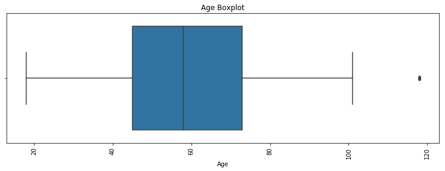

```python
plt.figure(figsize=(13, 4))
sns.boxplot(profile['age'])
plt.title('Age Boxplot')
plt.xlabel('Age')
plt.xticks(rotation = 90)
plt.show();
```

Form the about box plot, we can see that most of ages in our profile dataframe falls in-between **40** and **80**. We already notice one outlier which is **118**. Our median is around **58** years old.

What about income?

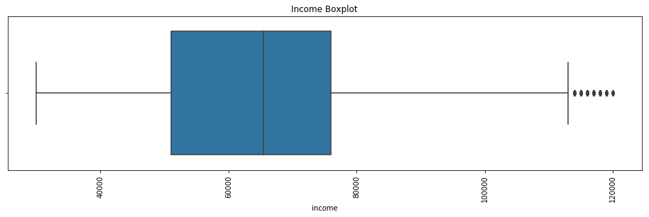

```python
plt.figure(figsize=(16, 4))
sns.boxplot(profile['income'])
plt.title('Income Boxplot')
plt.xlabel('income')
plt.xticks(rotation = 90)
plt.show();
```

Our boxplot shows that the median is around **65k** and most of incomes falls between **50k** and **78k**.

#### A2: What are the most common values for each column in each dataframe?

For Age, we have 85 different ages, so to make the graph look better I think we should divide ages to groups:

- Child: 0 - 12.
- Teen: 12 - 18.
- Young Adult: 18 - 21.
- Adult: 21 - 64.
- Elderly: 65+.

```python
profile['age'].value_counts().shape[0]
```

```
85
```

```python
# reference: https://twitter.com/justmarkham/status/1146040449678925824
profile['age_groups'] = pd.cut(profile.age, bins=[0, 12, 18, 21, 64, 200], labels=['child', 'teen', 'young adult', 'adult', 'elderly'])
```

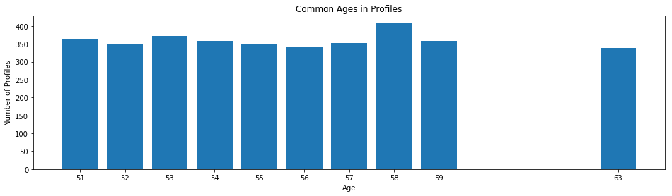

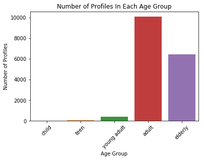

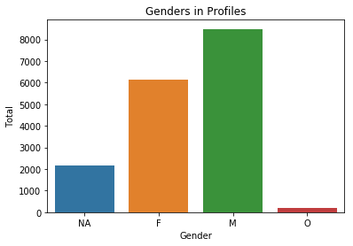

```python
# I am ignoring the outlier age 118
plt.figure(figsize=(16, 4))
top10_ages = profile['age'].value_counts()[1:].head(10).reset_index()
plt.bar(top10_ages['index'], top10_ages['age'])
plt.title('Common Ages in Profiles')
plt.ylabel('Number of Profiles')
plt.xlabel('Age')
plt.xticks(top10_ages['index'], rotation = 0)
plt.show();

sns.countplot(x='age_groups', data=profile)
plt.title('Number of Profiles In Each Age Group')
plt.ylabel('Number of Profiles')
plt.xlabel('Age Group')
plt.xticks(rotation = 45)
plt.show();

sns.countplot(profile['gender'])
plt.title('Genders in Profiles')
plt.ylabel('Total')
plt.xlabel('Gender')
plt.xticks(rotation = 0)
plt.show();
```

We can see that we have alot profile in the adult age group, ages between **21** and **64**, lets see more about this and look inside the adult age group and see how it is divided.

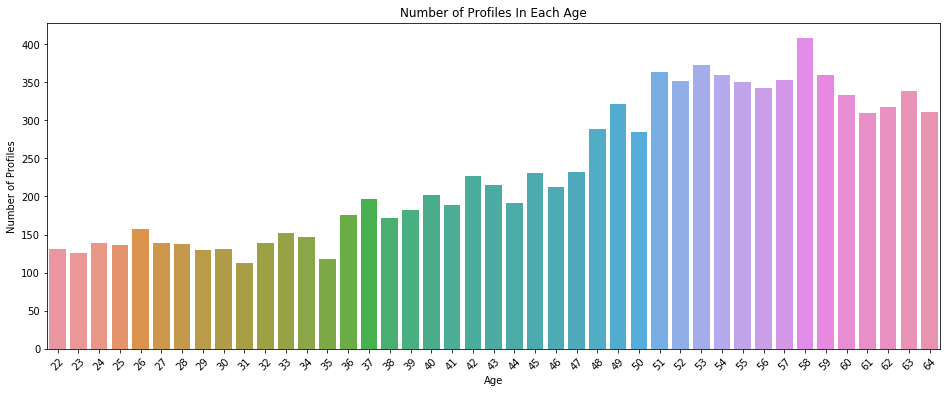

```python
adults = profile[profile['age_groups'] == 'adult']

plt.figure(figsize=(16, 6))
sns.countplot(adults['age'])
plt.title('Number of Profiles In Each Age')
plt.ylabel('Number of Profiles')
plt.xlabel('Age')
plt.xticks(rotation = 45)
plt.show();
```

For **become_member_on** column, because we have alot of dates, I will group it by month.

```python
profile['became_member_on_month'] = profile['became_member_on'].astype(str).str[:6]
```

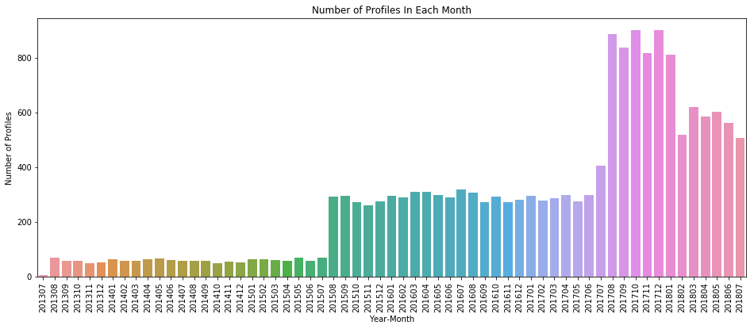

```python
plt.figure(figsize=(16, 6))
sns.countplot(profile['became_member_on_month'])
plt.title('Number of Profiles In Each Month')
plt.ylabel('Number of Profiles')
plt.xlabel('Year-Month')
plt.xticks(rotation = 90)
plt.show();
```

We can see that we did better job between **August 2017** and **January 2018**. We were able to get more than **800** new profiles monthly

For transcript dataframe, lets see the common values we have.

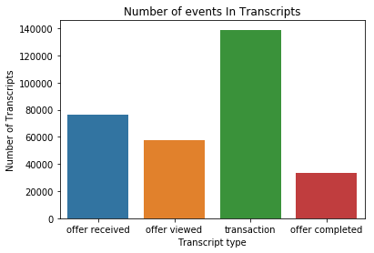

```python
sns.countplot(transcript['event'])
plt.title('Number of events In Transcripts')
plt.ylabel('Number of Transcripts')
plt.xlabel('Transcript type')
plt.xticks(rotation = 0)
plt.show();
```

#### A3: What is the average income for Starbucks customers?

```python
profile['income'].describe()['mean']
```

```
65404.991568296799
```

#### A4: What is the average age for Starbucks customers?

```python
profile['age'].describe()['mean']
```

```
62.531411764705879
```

#### A5: What are the most common promotion? and what are their types?

Here I will be looking for only completed promotions.

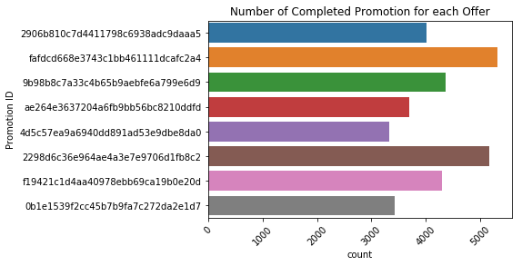

```
Offer ID: fafdcd668e3743c1bb461111dcafc2a4
Number of Completion: 5317
```

```python
completed_off_count = transcript[transcript['event'] == 'offer completed']

sns.countplot(y=completed_off_count['offer_id'])
plt.title('Number of Completed Promotion for each Offer')
plt.ylabel('Promotion ID')
plt.xticks(rotation = 45)
plt.show();

print(f'Offer ID: {completed_off_count["offer_id"].value_counts().index[0]}')
print(f'Number of Completion: {completed_off_count["offer_id"].value_counts().values[0]}')
```

Now lets look at the most common types of offers, to find that I need to get the offer type from the portfolio dataframe.

```python
def get_offer_type(offer_id):
    try:
        offer_type = portfolio[portfolio['id'] == offer_id]['offer_type'].values[0]
        return offer_type
    except:
        offer_type = 'NA'
        return offer_type

transcript['offer_type'] = transcript.apply(lambda x: get_offer_type(x['offer_id']), axis=1)
```

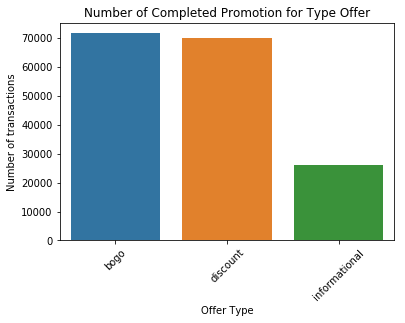

```python
sns.countplot(transcript[transcript['offer_type'] != 'NA']['offer_type'])
plt.title('Number of Completed Promotion for Type Offer')
plt.ylabel('Number of transactions')
plt.xlabel('Offer Type')
plt.xticks(rotation = 45)
plt.show();
```

As we saw in the above graph, it is pretty close between **BOGO** offers and **discount** offers.

#### A6: What is the least common promotion?

```python
print(f'Offer ID: {completed_off_count["offer_id"].value_counts().index[-1]}')
print(f'Number of Completion: {completed_off_count["offer_id"].value_counts().values[-1]}')
```

```
Offer ID: 4d5c57ea9a6940dd891ad53e9dbe8da0
Number of Completion: 3331
```

#### A7: Who are the most loyal customer (most transcripts)?

For this one, I will check offer completed and transactions event types.

```python
loyal_customer_count = transcript[(transcript['event'] == 'offer completed') | (transcript['event'] == 'transaction')].groupby(['person', 'event'])['amount'].sum().reset_index()
loyal_customer_count = loyal_customer_count.sort_values('amount', ascending=False).head(10)
count = 1

print(' ')
print(' *************** [ LEADERBOARD ] **************')
print(' ')
for idx, row in loyal_customer_count.iterrows():
    print(f'.------------------- [ #{count} ] ------------------.')
    print(f'| Profile ID: {row["person"]} |')
    print(f'| Number of Completed Offers:       {completed_off_count[(completed_off_count["person"] == row["person"]) & (completed_off_count["event"] == "offer completed")].shape[0]}          |')
    print(f'| Amount:                         ${row["amount"]}        |')
    print(f"'----------------------------------------------'")
    count += 1
```

```
 *************** [ LEADERBOARD ] **************

.------------------- [ #1 ] ------------------.
| Profile ID: 3c8d541112a74af99e88abbd0692f00e |
| Number of Completed Offers:       5          |
| Amount:                         $1606        |
'----------------------------------------------'
.------------------- [ #2 ] ------------------.
| Profile ID: f1d65ae63f174b8f80fa063adcaa63b7 |
| Number of Completed Offers:       6          |
| Amount:                         $1360        |
'----------------------------------------------'
.------------------- [ #3 ] ------------------.
| Profile ID: ae6f43089b674728a50b8727252d3305 |
| Number of Completed Offers:       3          |
| Amount:                         $1320        |
'----------------------------------------------'
.------------------- [ #4 ] ------------------.
| Profile ID: 626df8678e2a4953b9098246418c9cfa |
| Number of Completed Offers:       4          |
| Amount:                         $1314        |
'----------------------------------------------'
.------------------- [ #5 ] ------------------.
| Profile ID: 73afdeca19e349b98f09e928644610f8 |
| Number of Completed Offers:       5          |
| Amount:                         $1314        |
'----------------------------------------------'
.------------------- [ #6 ] ------------------.
| Profile ID: 52959f19113e4241a8cb3bef486c6412 |
| Number of Completed Offers:       5          |
| Amount:                         $1285        |
'----------------------------------------------'
.------------------- [ #7 ] ------------------.
| Profile ID: ad1f0a409ae642bc9a43f31f56c130fc |
| Number of Completed Offers:       3          |
| Amount:                         $1256        |
'----------------------------------------------'
.------------------- [ #8 ] ------------------.
| Profile ID: d240308de0ee4cf8bb6072816268582b |
| Number of Completed Offers:       5          |
| Amount:                         $1244        |
'----------------------------------------------'
.------------------- [ #9 ] ------------------.
| Profile ID: 946fc0d3ecc4492aa4cc06cf6b1492c3 |
| Number of Completed Offers:       4          |
| Amount:                         $1224        |
'----------------------------------------------'
.------------------- [ #10 ] ------------------.
| Profile ID: 6406abad8e2c4b8584e4f68003de148d |
| Number of Completed Offers:       3          |
| Amount:                         $1206        |
'----------------------------------------------'
```

#### A8: What are the most events we have in our transcripts?

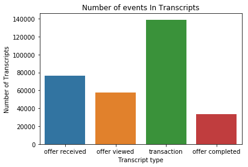

```python
sns.countplot(transcript['event'])
plt.title('Number of events In Transcripts')
plt.ylabel('Number of Transcripts')
plt.xlabel('Transcript type')
plt.xticks(rotation = 0)
plt.show();
```

Transaction have the most amount of rows in the transcript dataframe with around **140k**, almost half of our dataframe total.

### B. Multivariate Exploration:

#### B1: What is the most common promotion for children, teens, young adult, adult and elderly customors?

To find out, we need to get customer's age in the transcript dataframe. I created a function to get that from the profile dataframe (It takes time to run). I will ignore 'child' age group since we have no rows of it.

```python
def get_customer_age_group(profile_id):
    age_group = profile[profile['id'] == profile_id]['age_groups'].values[0]
    return age_group

transcript['age_group'] = transcript.apply(lambda x: get_customer_age_group(x['person']), axis=1)
```

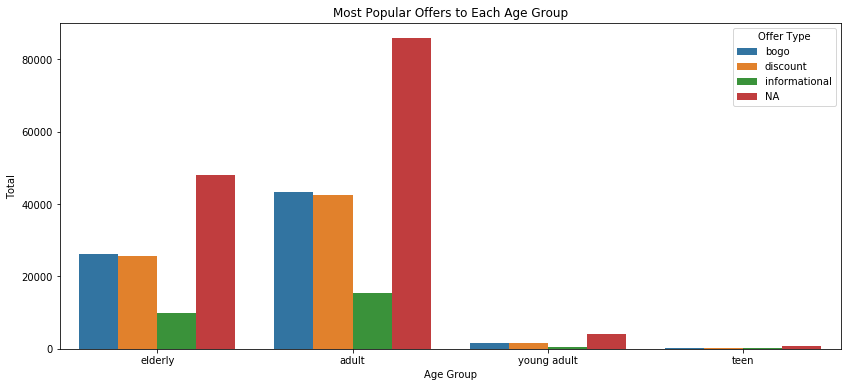

```python
plt.figure(figsize=(14, 6))
sns.countplot(x="age_group", hue="offer_type", data=transcript)
plt.title('Most Popular Offers to Each Age Group')
plt.ylabel('Total')
plt.xlabel('Age Group')
plt.xticks(rotation = 0)
plt.legend(title='Offer Type')
plt.show();
```

#### B2: From profiles, which get more income, males or females?

Here I ignored those who didn't tell their gender.

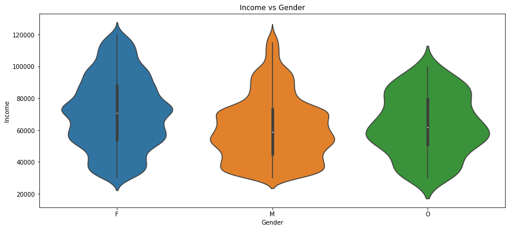

```python
plt.figure(figsize=(14, 6))
sns.violinplot(x=profile[profile['gender'] != 'NA']['gender'], y=profile['income'])
plt.title('Income vs Gender')
plt.ylabel('Income')
plt.xlabel('Gender')
plt.xticks(rotation = 0)
plt.show();
```

The graph above shows that income median (the white dot) for females (around **70k**) is higher than males (around **60k)** we can also see that for females the income spreads from **40k** to **100k**. For males most of them around **40k** to **70k** which close to median.

#### B3: What is the gender distribution in the transcript dataframe?

We need to add gender also here, I will make function to do so (It takes time to run).

```python
def get_customer_gender(profile_id):
    gender = profile[profile['id'] == profile_id]['gender'].values[0]
    return gender

transcript['gender'] = transcript.apply(lambda x: get_customer_gender(x['person']), axis=1)
```

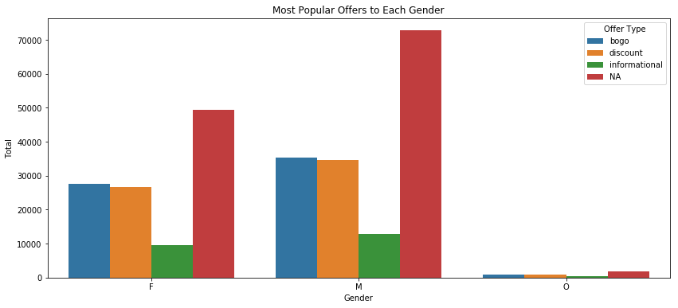

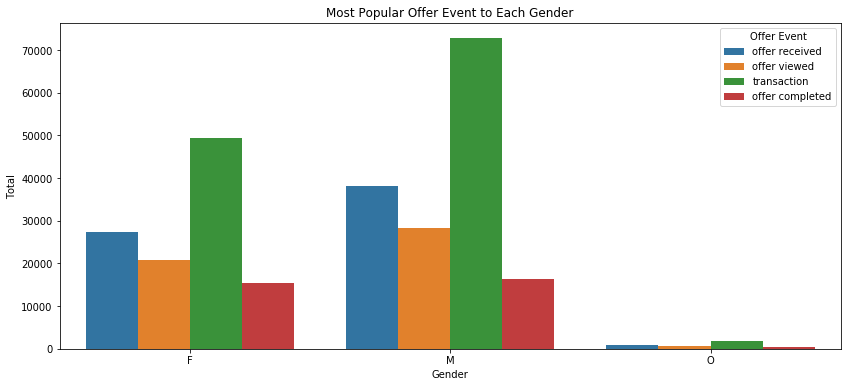

```
Number of males records 155690, and number of female records is 113101.
```

```python
plt.figure(figsize=(14, 6))
sns.countplot(x=transcript[transcript["gender"] != 'NA']['gender'], hue="offer_type", data=transcript)
plt.title('Most Popular Offers to Each Gender')
plt.ylabel('Total')
plt.xlabel('Gender')
plt.xticks(rotation = 0)
plt.legend(title='Offer Type')
plt.show();

plt.figure(figsize=(14, 6))
sns.countplot(x=transcript[transcript["gender"] != 'NA']['gender'], hue="event", data=transcript)
plt.title('Most Popular Offer Event to Each Gender')
plt.ylabel('Total')
plt.xlabel('Gender')
plt.xticks(rotation = 0)
plt.legend(title='Offer Event')
plt.show();

print(f'Number of males records {transcript[transcript["gender"] == "M"].shape[0]}, and number of female records is {transcript[transcript["gender"] == "F"].shape[0]}.')
```

From the two graphs above we can see that males received offers more than females. Both genders seems to reflect on those offers similarly. Around half of 80% of offers received were viewed by both genders, but it seems that females would complete those offers more than males. The numbers are:

```python
total_trans_g_o = transcript[transcript["gender"] != 'NA'].groupby(['gender','offer_type']).count()
total_trans_g_e = transcript[transcript["gender"] != 'NA'].groupby(['gender','event']).count()
```

```python
total_trans_g_o, total_trans_g_e
```

```
(                      event  person   time  offer_id  amount  reward  \
 gender offer_type
 F      NA             49382   49382  49382     49382   49382   49382
        bogo           27619   27619  27619     27619   27619   27619
        discount       26652   26652  26652     26652   26652   26652
        informational   9448    9448   9448      9448    9448    9448
 M      NA             72794   72794  72794     72794   72794   72794
        bogo           35301   35301  35301     35301   35301   35301
        discount       34739   34739  34739     34739   34739   34739
        informational  12856   12856  12856     12856   12856   12856
 O      NA              1781    1781   1781      1781    1781    1781
        bogo             914     914    914       914     914     914
        discount         920     920    920       920     920     920
        informational    356     356    356       356     356     356

                       age_group
 gender offer_type
 F      NA                 49382
        bogo               27619
        discount           26652
        informational       9448
 M      NA                 72794
        bogo               35301
        discount           34739
        informational      12856
 O      NA                  1781
        bogo                 914
        discount             920
        informational        356  ,
                         person   time  offer_id  amount  reward  offer_type  \
 gender event
 F      offer completed   15477  15477     15477   15477   15477       15477
        offer received    27456  27456     27456   27456   27456       27456
        offer viewed      20786  20786     20786   20786   20786       20786
        transaction       49382  49382     49382   49382   49382       49382
 M      offer completed   16466  16466     16466   16466   16466       16466
        offer received    38129  38129     38129   38129   38129       38129
        offer viewed      28301  28301     28301   28301   28301       28301
        transaction       72794  72794     72794   72794   72794       72794
 O      offer completed     501    501       501     501     501         501
        offer received      916    916       916     916     916         916
        offer viewed        773    773       773     773     773         773
        transaction        1781   1781      1781    1781    1781        1781

                         age_group
 gender event
 F      offer completed      15477
        offer received       27456
        offer viewed         20786
        transaction          49382
 M      offer completed      16466
        offer received       38129
        offer viewed         28301
        transaction          72794
 O      offer completed        501
        offer received         916
        offer viewed           773
        transaction           1781  )
```

```python
total_trans_go_o_t = total_trans_g_o.loc[('F')]['event'].sum()
total_trans_go_o_tt = total_trans_g_o.loc[('M')]['event'].sum()
total_trans_go_o_t_offers_f = total_trans_g_o.loc[('F')].loc[['bogo', 'discount', 'informational']]['event'].sum()
total_trans_go_o_t_offers_m = total_trans_g_o.loc[('M')].loc[['bogo', 'discount', 'informational']]['event'].sum()

print('For Females:')
print(f'Total transcipts is: {total_trans_go_o_t}.')
print(f"Number of bogo offers: {total_trans_g_o.loc[('F', 'bogo')].values[0]}, {round((total_trans_g_o.loc[('F', 'bogo')].values[0]/total_trans_go_o_t_offers_f)*100,2)}% of total.")
print(f"Number of discount offers: {total_trans_g_o.loc[('F', 'discount')].values[0]}, {round((total_trans_g_o.loc[('F', 'discount')].values[0]/total_trans_go_o_t_offers_f)*100,2)}% of total.")
print(f"Number of informational offers: {total_trans_g_o.loc[('F', 'informational')].values[0]}, {round((total_trans_g_o.loc[('F', 'informational')].values[0]/total_trans_go_o_t_offers_f)*100,2)}% of total.")

print(f"Number of offer completed: {total_trans_g_e.loc[('F', 'offer completed')].values[0]}, {round((total_trans_g_e.loc[('F', 'offer completed')].values[0]/total_trans_g_e.loc[('F', 'offer received')].values[0])*100,2)}% of total offers received.")
print(f"Number of offer received: {total_trans_g_e.loc[('F', 'offer received')].values[0]}, {round((total_trans_g_e.loc[('F', 'offer received')].values[0]/total_trans_go_o_t_offers_f)*100,2)}% of total.")
print(f"Number of offer viewed: {total_trans_g_e.loc[('F', 'offer viewed')].values[0]}, {round((total_trans_g_e.loc[('F', 'offer viewed')].values[0]/total_trans_go_o_t_offers_f)*100,2)}% of total.")
print(f"Number of transaction: {total_trans_g_e.loc[('F', 'transaction')].values[0]}, {round((total_trans_g_e.loc[('F', 'transaction')].values[0]/total_trans_go_o_t)*100,2)}% of total.")

print('\nFor Males:')
print(f'Total transcipts is: {total_trans_go_o_tt}.')
print(f"Number of bogo offers: {total_trans_g_o.loc[('M', 'bogo')].values[0]}, {round((total_trans_g_o.loc[('M', 'bogo')].values[0]/total_trans_go_o_t_offers_m)*100,2)}% of total.")
print(f"Number of discount offers: {total_trans_g_o.loc[('M', 'discount')].values[0]}, {round((total_trans_g_o.loc[('M', 'discount')].values[0]/total_trans_go_o_t_offers_m)*100,2)}% of total.")
print(f"Number of informational offers: {total_trans_g_o.loc[('M', 'informational')].values[0]}, {round((total_trans_g_o.loc[('M', 'informational')].values[0]/total_trans_go_o_t_offers_m)*100,2)}% of total.")

print(f"Number of offer completed: {total_trans_g_e.loc[('M', 'offer completed')].values[0]}, {round((total_trans_g_e.loc[('M', 'offer completed')].values[0]/total_trans_g_e.loc[('M', 'offer received')].values[0])*100,2)}% of total offers received.")
print(f"Number of offer received: {total_trans_g_e.loc[('M', 'offer received')].values[0]}, {round((total_trans_g_e.loc[('M', 'offer received')].values[0]/total_trans_go_o_t_offers_m)*100,2)}% of total.")
print(f"Number of offer viewed: {total_trans_g_e.loc[('M', 'offer viewed')].values[0]}, {round((total_trans_g_e.loc[('M', 'offer viewed')].values[0]/total_trans_go_o_t_offers_m)*100,2)}% of total.")
print(f"Number of transaction: {total_trans_g_e.loc[('M', 'transaction')].values[0]}, {round((total_trans_g_e.loc[('M', 'transaction')].values[0]/total_trans_go_o_t)*100,2)}% of total.")
```

```
For Females:
Total transcipts is: 113101.
Number of bogo offers: 27619, 43.34% of total.
Number of discount offers: 26652, 41.83% of total.
Number of informational offers: 9448, 14.83% of total.
Number of offer completed: 15477, 56.37% of total offers received.
Number of offer received: 27456, 43.09% of total.
Number of offer viewed: 20786, 32.62% of total.
Number of transaction: 49382, 43.66% of total.

For Males:
Total transcipts is: 155690.
Number of bogo offers: 35301, 42.58% of total.
Number of discount offers: 34739, 41.91% of total.
Number of informational offers: 12856, 15.51% of total.
Number of offer completed: 16466, 43.18% of total offers received.
Number of offer received: 38129, 46.0% of total.
Number of offer viewed: 28301, 34.14% of total.
Number of transaction: 72794, 64.36% of total.
```

#### B4: Who takes long time to achieve each promotion goal and from which gender, age, income?

They are pretty close if it not similar. Both males and females take about **15** days to complete and offer.

```python
tran_avg_len_g_f = transcript.groupby(['gender', 'offer_id'])['time'].mean().reset_index()
tran_avg_len_g_m = transcript.groupby(['gender', 'offer_id'])['time'].mean().reset_index()
tran_avg_len_g_f = tran_avg_len_g_f[tran_avg_len_g_f['offer_id'] == '']
tran_avg_len_g_m = tran_avg_len_g_m[tran_avg_len_g_m['offer_id'] == '']
print(tran_avg_len_g_f[tran_avg_len_g_f['gender'] == 'F']['time'].values[0], tran_avg_len_g_f[tran_avg_len_g_f['gender'] == 'F']['time'].values[0] / 24)
print(tran_avg_len_g_f[tran_avg_len_g_f['gender'] == 'M']['time'].values[0], tran_avg_len_g_f[tran_avg_len_g_f['gender'] == 'M']['time'].values[0] / 24)
```

```
380.86002997 15.8691679154
381.727312691 15.9053046954
```

#### B5: What is the average length between two transcript for the same customer?

The mean time it tekes a customer to complete an offer is around **16** days (390 hours)

```python
tran_avg_len = transcript.groupby(['person', 'offer_id'])['time'].mean().reset_index()
tran_avg_len = tran_avg_len[tran_avg_len['offer_id'] == '']
tran_avg_len['time'].mean(), tran_avg_len['time'].mean() / 24
```

```
(390.04931656772442, 16.252054856988519)
```

#### B6: Which type of promotions each gender likes (offer_type)?

We can see that both genders like bogo and discount offers and they have the same reaction to informational offers, they both seem to be not intersted to it.

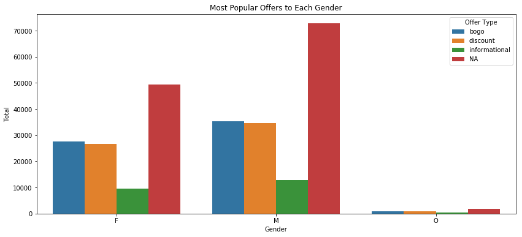

```python
plt.figure(figsize=(14, 6))
sns.countplot(x=transcript[transcript["gender"] != 'NA']['gender'], hue="offer_type", data=transcript)
plt.title('Most Popular Offers to Each Gender')
plt.ylabel('Total')
plt.xlabel('Gender')
plt.xticks(rotation = 0)
plt.legend(title='Offer Type')
plt.show();
```

#### B7: From each offer received by customer, how many they completed?

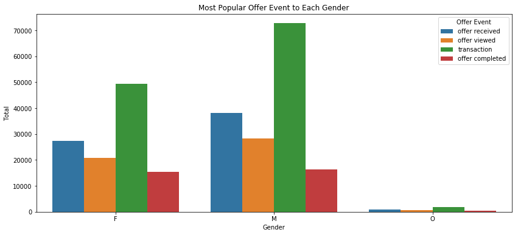

```python
plt.figure(figsize=(14, 6))
sns.countplot(x=transcript[transcript["gender"] != 'NA']['gender'], hue="event", data=transcript)
plt.title('Most Popular Offer Event to Each Gender')
plt.ylabel('Total')
plt.xlabel('Gender')
plt.xticks(rotation = 0)
plt.legend(title='Offer Event')
plt.show();
```

```python
print('For Females:')
print(f"Number of offer completed: {total_trans_g_e.loc[('F', 'offer completed')].values[0]}, {round((total_trans_g_e.loc[('F', 'offer completed')].values[0]/total_trans_g_e.loc[('F', 'offer received')].values[0])*100,2)}% of total offers received.")
print(f"Number of offer received: {total_trans_g_e.loc[('F', 'offer received')].values[0]}, {round((total_trans_g_e.loc[('F', 'offer received')].values[0]/total_trans_go_o_t_offers_f)*100,2)}% of total.")
print(f"Number of offer viewed: {total_trans_g_e.loc[('F', 'offer viewed')].values[0]}, {round((total_trans_g_e.loc[('F', 'offer viewed')].values[0]/total_trans_go_o_t_offers_f)*100,2)}% of total.")
print(f"Number of transaction: {total_trans_g_e.loc[('F', 'transaction')].values[0]}, {round((total_trans_g_e.loc[('F', 'transaction')].values[0]/total_trans_go_o_t)*100,2)}% of total.")

print('\nFor Males:')
print(f"Number of offer completed: {total_trans_g_e.loc[('M', 'offer completed')].values[0]}, {round((total_trans_g_e.loc[('M', 'offer completed')].values[0]/total_trans_g_e.loc[('M', 'offer received')].values[0])*100,2)}% of total offers received.")
print(f"Number of offer received: {total_trans_g_e.loc[('M', 'offer received')].values[0]}, {round((total_trans_g_e.loc[('M', 'offer received')].values[0]/total_trans_go_o_t_offers_m)*100,2)}% of total.")
print(f"Number of offer viewed: {total_trans_g_e.loc[('M', 'offer viewed')].values[0]}, {round((total_trans_g_e.loc[('M', 'offer viewed')].values[0]/total_trans_go_o_t_offers_m)*100,2)}% of total.")
print(f"Number of transaction: {total_trans_g_e.loc[('M', 'transaction')].values[0]}, {round((total_trans_g_e.loc[('M', 'transaction')].values[0]/total_trans_go_o_t)*100,2)}% of total.")
```

```
For Females:
Number of offer completed: 15477, 56.37% of total offers received.
Number of offer received: 27456, 43.09% of total.
Number of offer viewed: 20786, 32.62% of total.
Number of transaction: 49382, 43.66% of total.

For Males:
Number of offer completed: 16466, 43.18% of total offers received.
Number of offer received: 38129, 46.0% of total.
Number of offer viewed: 28301, 34.14% of total.
Number of transaction: 72794, 64.36% of total.
```

Females completed **56%** of the offers they received, it is **13%** more than males, but males made more transactions than females, **64%** to **43%**.

### *Note*

Now since I did alot of changes to the transcript dataframe and it takes time to do the changes evry run, i'll convert the dataframe to csv file and just run it whenever I come back to work on the project. I will add one last column for the datafame which is income that might help us in the model (It takes time to run).

```python
def get_customer_income(profile_id):
    income = profile[profile['id'] == profile_id]['income'].values[0]
    return income

transcript['income'] = transcript.apply(lambda x: get_customer_income(x['person']), axis=1)
```

```python
transcript.to_csv('transcript_updated.csv')
```

```python
transcript_up = pd.read_csv('transcript_updated.csv').iloc[:, 1:]
```

```python
transcript_up.isna().sum()
```

```
event              0
person             0
time               0
offer_id      138953
amount             0
reward             0
offer_type    138953
age_group          0
gender         33772
income             0
dtype: int64
```

Before working on the model I will take care of the NaN values in gender, offer_type and offer_id. offer_id and offer_type are NaN because theose records are transactions, so they are not offer received, viewed or completed, because of that, we have the same number of NaNs in offer_type since they are not offers. I will replace NaNs in both columns with NA. Similarly in gender, some didn't tell their gender and we saw that before in profile dataframe, and we replaced it with NA.

```python
fill_na = ['offer_id', 'offer_type', 'gender']
for i in fill_na:
    transcript_up[i] = transcript_up[i].fillna('NA')
transcript_up.isna().sum()
```

```
event         0
person        0
time          0
offer_id      0
amount        0
reward        0
offer_type    0
age_group     0
gender        0
income        0
dtype: int64
```

### 2. Modeling:

In this part, I will try to make a model that can identify which kind of offers we should give a customer. First lets take quick look at our final dataframe before modeling.

```python
transcript_up.head(5)
```

|  | event | person | time | offer_id | amount | reward | offer_type | age_group | gender | income |
| --- | --- | --- | --- | --- | --- | --- | --- | --- | --- | --- |
| 0 | offer received | 78afa995795e4d85b5d9ceeca43f5fef | 0 | 9b98b8c7a33c4b65b9aebfe6a799e6d9 | 0 | 0 | bogo | elderly | F | 100000.000000 |
| 1 | offer received | a03223e636434f42ac4c3df47e8bac43 | 0 | 0b1e1539f2cc45b7b9fa7c272da2e1d7 | 0 | 0 | discount | elderly | NA | 65404.991568 |
| 2 | offer received | e2127556f4f64592b11af22de27a7932 | 0 | 2906b810c7d4411798c6938adc9daaa5 | 0 | 0 | discount | elderly | M | 70000.000000 |
| 3 | offer received | 8ec6ce2a7e7949b1bf142def7d0e0586 | 0 | fafdcd668e3743c1bb461111dcafc2a4 | 0 | 0 | discount | elderly | NA | 65404.991568 |
| 4 | offer received | 68617ca6246f4fbc85e91a2a49552598 | 0 | 4d5c57ea9a6940dd891ad53e9dbe8da0 | 0 | 0 | bogo | elderly | NA | 65404.991568 |

```python
transcript_up.dtypes
```

```
event          object
person         object
time            int64
offer_id       object
amount          int64
reward          int64
offer_type     object
age_group      object
gender         object
income        float64
dtype: object
```

Because my model will guess the offer_type, I will only get those transcripts with offer id's.

```python
transcript_up = transcript_up[transcript_up['offer_id'] != 'NA']
```

Now, we should split our dataframe to features and target. Our features here are:

- Event. (Will be replaced from categorical to numerical)
- Time.
- Offer_id. (Will be replaced from categorical to numerical)
- Amount.
- Reward.
- Age_group. (Will be replaced from categorical to numerical)
- Gender. (Will be replaced from categorical to numerical)
- Income.

And my target is offer_type. For my target, I will replace texts with numbers. Where **BOGO = 1**, **discount = 2**, **informational = 3**.

```python
# reference: https://www.datacamp.com/community/tutorials/categorical-data
labels_event = transcript_up['event'].astype('category').cat.categories.tolist()
replace_map_comp_event = {'event' : {k: v for k,v in zip(labels_event,list(range(1,len(labels_event)+1)))}}
print(replace_map_comp_event)

labels_offer_id = transcript_up['offer_id'].astype('category').cat.categories.tolist()
replace_map_comp_offer_id = {'offer_id' : {k: v for k,v in zip(labels_offer_id,list(range(1,len(labels_offer_id)+1)))}}
print(replace_map_comp_offer_id)

labels_age_group = transcript_up['age_group'].astype('category').cat.categories.tolist()
replace_map_comp_age_group = {'age_group' : {k: v for k,v in zip(labels_age_group,list(range(1,len(labels_age_group)+1)))}}
print(replace_map_comp_age_group)

labels_gender = transcript_up['gender'].astype('category').cat.categories.tolist()
replace_map_comp_gender = {'gender' : {k: v for k,v in zip(labels_gender,list(range(1,len(labels_gender)+1)))}}
print(replace_map_comp_gender)
```

[output not shown]

```python
# reference: https://www.datacamp.com/community/tutorials/categorical-data
labels_offer_type = transcript_up['offer_type'].astype('category').cat.categories.tolist()
replace_map_comp_offer_type = {'offer_type' : {k: v for k,v in zip(labels_offer_type,list(range(1,len(labels_offer_type)+1)))}}
print(replace_map_comp_offer_type)
```

```
{'offer_type': {'bogo': 1, 'discount': 2, 'informational': 3}}
```

```python
# replace categorical with numerical
transcript_up.replace(replace_map_comp_event, inplace=True)
transcript_up.replace(replace_map_comp_offer_id, inplace=True)
transcript_up.replace(replace_map_comp_age_group, inplace=True)
transcript_up.replace(replace_map_comp_gender, inplace=True)

transcript_up.replace(replace_map_comp_offer_type, inplace=True)
```

```python
transcript_up.head()
```

|  | event | person | time | offer_id | amount | reward | offer_type | age_group | gender | income |
| --- | --- | --- | --- | --- | --- | --- | --- | --- | --- | --- |
| 0 | 2 | 78afa995795e4d85b5d9ceeca43f5fef | 0 | 7 | 0 | 0 | 1 | 2 | 1 | 100000.000000 |
| 1 | 2 | a03223e636434f42ac4c3df47e8bac43 | 0 | 1 | 0 | 0 | 2 | 2 | 3 | 65404.991568 |
| 2 | 2 | e2127556f4f64592b11af22de27a7932 | 0 | 3 | 0 | 0 | 2 | 2 | 2 | 70000.000000 |
| 3 | 2 | 8ec6ce2a7e7949b1bf142def7d0e0586 | 0 | 10 | 0 | 0 | 2 | 2 | 3 | 65404.991568 |
| 4 | 2 | 68617ca6246f4fbc85e91a2a49552598 | 0 | 5 | 0 | 0 | 1 | 2 | 3 | 65404.991568 |

```python
# Split the data into features and target label
target = transcript_up['offer_type']
features = transcript_up.drop(['person', 'offer_type'], axis = 1)
```

```python
features.head()
```

|  | event | time | offer_id | amount | reward | age_group | gender | income |
| --- | --- | --- | --- | --- | --- | --- | --- | --- |
| 0 | 2 | 0 | 7 | 0 | 0 | 2 | 1 | 100000.000000 |
| 1 | 2 | 0 | 1 | 0 | 0 | 2 | 3 | 65404.991568 |
| 2 | 2 | 0 | 3 | 0 | 0 | 2 | 2 | 70000.000000 |
| 3 | 2 | 0 | 10 | 0 | 0 | 2 | 3 | 65404.991568 |
| 4 | 2 | 0 | 5 | 0 | 0 | 2 | 3 | 65404.991568 |

```python
target.head()
```

```
0    1
1    2
2    2
3    2
4    1
Name: offer_type, dtype: int64
```

We should normalize the numerical values ( Time, amount, reward, income ) because we will use them as features.

```python
from sklearn.preprocessing import MinMaxScaler

scaler = MinMaxScaler()
to_normalize = ['time', 'amount', 'reward', 'income']

features[to_normalize] = scaler.fit_transform(features[to_normalize])
features.head()
```

|  | event | time | offer_id | amount | reward | age_group | gender | income |
| --- | --- | --- | --- | --- | --- | --- | --- | --- |
| 0 | 2 | 0.0 | 7 | 0.0 | 0.0 | 2 | 1 | 0.777778 |
| 1 | 2 | 0.0 | 1 | 0.0 | 0.0 | 2 | 3 | 0.393389 |
| 2 | 2 | 0.0 | 3 | 0.0 | 0.0 | 2 | 2 | 0.444444 |
| 3 | 2 | 0.0 | 10 | 0.0 | 0.0 | 2 | 3 | 0.393389 |
| 4 | 2 | 0.0 | 5 | 0.0 | 0.0 | 2 | 3 | 0.393389 |

#### Creating training and testing sets

```python
from sklearn.model_selection import train_test_split, GridSearchCV
```

```python
X_train, X_test, y_train, y_test = train_test_split(features, target, random_state=0)
```

```python
print('Training Features Shape:', X_train.shape)
print('Training Labels Shape:', y_train.shape)
print('Testing Features Shape:', X_test.shape)
print('Testing Labels Shape:', y_test.shape)
```

```
Training Features Shape: (125685, 8)
Training Labels Shape: (125685,)
Testing Features Shape: (41896, 8)
Testing Labels Shape: (41896,)
```

### Metrics:

Since we have a simple classification problem, I will use accuracy to evaluate my models. We want to see how well our model by seeing the number of correct predictions vs total number of predicitons.

I'll try different models to pick the best out of them.

#### 1. LogisticRegression

```python
# reference: https://towardsdatascience.com/random-forest-in-python-24d0893d51c0
def pred_score(model):
    pred = model.predict(X_test)
    # Calculate the absolute errors
    errors = abs(pred - y_test)
    # Calculate mean absolute percentage error
    mape = 100 * (errors / y_test)
    accuracy = 100 - np.mean(mape)
    return round(accuracy, 2)
```

```python
from sklearn.linear_model import LogisticRegression

logreg = LogisticRegression()

logreg.fit(X_train, y_train)
print(f'Accuracy of Logistic regression classifier on training set: {round(logreg.score(X_train, y_train)*100,2)}%.')
print(f'Prediction Accuracy: {pred_score(logreg)}%')
```

```
Accuracy of Logistic regression classifier on training set: 65.39%.
Prediction Accuracy: 80.64%
```

#### 2. K-Nearest Neighbors

```python
from sklearn.neighbors import KNeighborsClassifier

knn = KNeighborsClassifier()

knn.fit(X_train, y_train)
print(f'Accuracy of K-NN classifier on training set: {round(knn.score(X_train, y_train)*100,2)}%.')
print(f'Prediction Accuracy: {pred_score(knn)}%')
```

```
Accuracy of K-NN classifier on training set: 100.0%.
Prediction Accuracy: 100.0%
```

#### 3. Decision Tree

```python
from sklearn.tree import DecisionTreeClassifier

dt = DecisionTreeClassifier()

dt.fit(X_train, y_train)
print(f'Accuracy of Decision Tree classifier on training set: {round(dt.score(X_train, y_train)*100,2)}%.')
print(f'Prediction Accuracy: {pred_score(dt)}%')
```

```
Accuracy of Decision Tree classifier on training set: 100.0%.
Prediction Accuracy: 100.0%
```

#### 4. Support Vector Machine

```python
from sklearn.svm import SVC

svm = SVC()

svm.fit(X_train, y_train)
print(f'Accuracy of SVM classifier on training set: {round(svm.score(X_train, y_train)*100,2)}%.')
print(f'Prediction Accuracy: {pred_score(svm)}%')
```

```
Accuracy of SVM classifier on training set: 100.0%.
Prediction Accuracy: 100.0%
```

#### 5. Naive Bayes

```python
from sklearn.naive_bayes import GaussianNB

gnb = GaussianNB()
gnb.fit(X_train, y_train)
print(f'Accuracy of SVM classifier on training set: {round(gnb.score(X_train, y_train)*100,2)}%.')
print(f'Prediction Accuracy: {pred_score(gnb)}%')
```

```
Accuracy of SVM classifier on training set: 48.5%.
Prediction Accuracy: 25.06%
```

#### 6. Random Forest

```python
from sklearn.ensemble import RandomForestRegressor

rf = RandomForestRegressor(n_estimators = 100, random_state = 42)

rf.fit(X_train, y_train)
print(f'Accuracy of SVM classifier on training set: {round(rf.score(X_train, y_train)*100,2)}%.')
print(f'Prediction Accuracy: {pred_score(rf)}%')
```

```
Accuracy of SVM classifier on training set: 100.0%.
Prediction Accuracy: 100.0%
```

### Models Results

```python
# reference: https://stackoverflow.com/a/52768022
models = [logreg, knn, dt, svm, gnb, rf]
model_names = [type(n).__name__ for n in models]
tr_accuracy = [x.score(X_train, y_train)*100 for x in models]
pred_accuracy = [pred_score(y) for y in models]
```

```python
results = [tr_accuracy, pred_accuracy]
results_df = pd.DataFrame(results, columns = model_names, index=['Training Accuracy', 'Predicting Accureacy'])
results_df
```

|  | LogisticRegression | KNeighborsClassifier | DecisionTreeClassifier | SVC | GaussianNB | RandomForestRegressor |
| --- | --- | --- | --- | --- | --- | --- |
| Training Accuracy | 65.386482 | 99.997613 | 100.0 | 100.0 | 48.501412 | 100.0 |
| Predicting Accureacy | 80.640000 | 100.000000 | 100.0 | 100.0 | 25.060000 | 100.0 |

From the previous table, we can see that we scored 100% accuracy in the training and testing datasets on 4 models. To avoid overfitting I will choose **Logistic Regression** since it got good results 65% on training and 80% on testing datasets. **Logistic Regression** is better used here since we have few binomial outcomes ( BOGO = 1, discount = 2, informational = 3 ). It is good here because we have good amount of data to work with.

### Model Improvements

The result from my Logistic Regression is good enough and we got fair number and avoided overfitting. But lets try to improve it little bit.

```python
# Tuning to get better accuracy
dual = [True, False]
max_iter = [100, 120, 140, 160]
C = [1.0,1.5]
param_grid = dict(dual = dual, max_iter = max_iter, C = C)

lr = LogisticRegression(penalty='l2')
grid = GridSearchCV(estimator = lr, param_grid = param_grid, cv = 3, n_jobs = -1)
grid_result = grid.fit(X_train, y_train)

print(f'Best Score: {grid_result.best_score_}')
print(f'Best params: {grid_result.best_params_}')
```

```
Best Score: 0.6563392608505391
Best params: {'C': 1.5, 'dual': True, 'max_iter': 140}
```

We improve slightly, 0.3% more. I still think it is good as it is and we don't need to try to get better results.

### Conclusion

In this project, I tried to analyze and make model to predict the best offer to give a Starbucks customer. First I explored the data and see what I have to change before start the analysis. Then I did some exploratory analysis on the data after cleaning. From that analysis I found out that most favorite type of offers are **Buy One Get One** (BOGO) offers and **Discount** offers. I digged deep to see who and what type of customers we have and noticed that **Females** tend to complete offers more than males with **56%** completion of the offers they received. Where **Males** completed only **43.18%** from the offers they received. But our current data shows that we gave **males** more offers since they have more transactions than females with total number of **72794** transactions, where females only had **49382** transactions. In conclusion, the company should give more offers to **Females** than **Males** since they have more completed offers. And they should focus more on **BOGO** and **Discount** offers since they are the one that tend to make customers buy more.

### Improvements

I think I got to a point where we have good results and we understand the data we have very well. But to make our results even better, I would try to improve my data collection and fix issues I have with NaN values. I will also try to get even more data like location and when the transaction were completed, which branch and what time of the day. All these data can help us know when and where to give our offers. Also having more data is always good think to help us improve our model results.